# Blackjack Strategies as a Simplified Bernoulli Model

Semesterarbeit Wahrscheinlichkeitsrechnung FS26

Aisosa Omokaro & Thiveja Thirukumar

2026-05-10

## Fragestellung

**Welche vereinfachte Blackjack-Strategie erzielt über 200 Runden die höchste Gewinnwahrscheinlichkeit?**

- Vergleich von **vier Strategien**: Basic, Aggressive, Random und Martingale.
- Jede Runde wird als **Bernoulli-artiger Versuch** modelliert: Gewinn = 1, Nicht-Gewinn = 0.
- Ziel: Strategien anhand von Gewinnwahrscheinlichkeit, Endkapital und Kapitalverlauf vergleichen.

## Warum dieses Thema?

- Blackjack verbindet **Zufall** und **Entscheidungsregeln**.
- Das Spiel lässt sich als **stochastischer Prozess** mit aufeinanderfolgenden Zufallsexperimenten modellieren.
- Strategien können mit einer Monte-Carlo-Simulation direkt verglichen werden.
- Das Thema passt gut zum Modul, weil Wahrscheinlichkeitsverteilungen und Simulation kombiniert werden.

## Modellidee

Wir betrachten eine **vereinfachte Version von Blackjack**.

- Standarddeck mit 52 Karten.
- Ass zählt als 11, bei Bedarf als 1.
- Dealer zieht immer bis mindestens 17.
- Keine Splits, kein Double Down, keine Versicherung.
- Unentschieden wird als **Nicht-Gewinn** gezählt.

## Strategien

| Strategie | Regel |
| --- | --- |
| **Basic** | Hit bei Summe < 17, sonst Stand |
| **Aggressive** | Hit bei Summe < 19, sonst Stand |
| **Random** | Hit oder Stand zufällig |
| **Martingale** | Gleiche Spielregel wie Basic, aber Einsatz nach Verlust verdoppeln |

## Modellannahmen

- Jeder simulierte Spieler startet mit **CHF 100**.
- Standard-Einsatz: **CHF 5** pro Runde.
- Bei Martingale wird nach einem Verlust der Einsatz verdoppelt.
- Jeder Spieler spielt **genau 200 Runden**.
- Es werden **10’000 Spieler pro Strategie** simuliert.

## Verteilungen

- **Bernoulli-Verteilung:** Eine Runde endet in Gewinn (1) oder Nicht-Gewinn (0).
- **Summe von Bernoulli-Versuchen:** Die Anzahl Gewinne in 200 Runden ergibt sich als Summe vieler 0/1-Ausgänge.
- **Empirische Verteilung:** Das Endkapital wird aus der Simulation beobachtet und grafisch ausgewertet.

## Simulationsablauf

1. Karten mischen und Hände für Spieler und Dealer ziehen.
2. Strategie-Regel anwenden.
3. Runde als Gewinn oder Nicht-Gewinn codieren.
4. Kapital aktualisieren.
5. Prozess für 200 Runden wiederholen.
6. Für jede Strategie 10’000-mal simulieren.

## R-Code: zentrale Idee

```r
# Bernoulli-Ausgang: Gewinn = 1, alles andere = 0
# if (player_sum > 21)         return(0)
# if (dealer_sum > 21)         return(1)
# if (player_sum > dealer_sum) return(1)
# return(0)
```

**Kernidee:** Jede Runde wird zu einer 0/1-Zufallsvariable vereinfacht.

## Kennzahlen

Die Strategien werden mit drei Grössen verglichen:

- **Geschätzte Gewinnwahrscheinlichkeit**
- **Durchschnittliches Endkapital**
- **Anteil der Spieler mit mehr als CHF 100 Endkapital**

## Ergebnisse

| Strategie | Ø Gewinnwahrsch. (%) | Ø Endkapital (CHF) | Anteil > 100 CHF (%) |
| --- | --- | --- | --- |
| aggressive | 36.3 | -173.4 | 0.0 |
| basic | 40.9 | -81.8 | 0.3 |
| martingale | 41.0 | -146.7 | 1.4 |
| random | 31.5 | -269.5 | 0.0 |

## Grafik 1

### Geschätzte Gewinnwahrscheinlichkeit

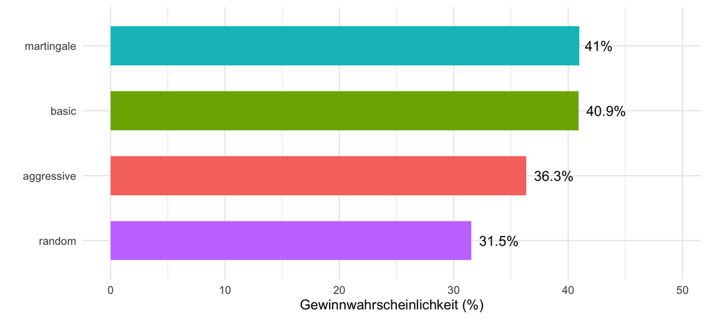

- Höherer Wert = mehr gewonnene Runden über 200 Runden
- Beantwortet direkt unsere Fragestellung

## Grafik 2

### Empirische Endkapitalverteilung

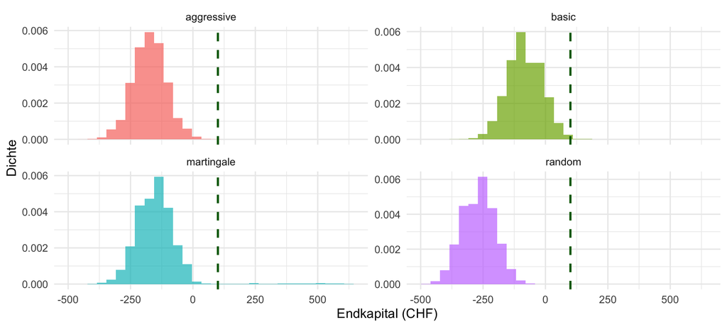

- Grüne Linie = Startkapital CHF 100
- Zeigt Streuung der Endresultate pro Strategie

## Grafik 3

### Durchschnittlicher Kapitalverlauf

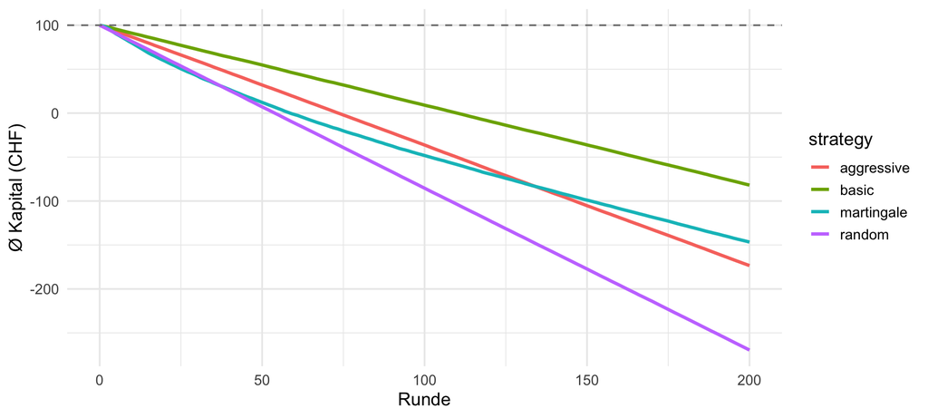

## Antwort auf die Fragestellung

- Die Simulation zeigt, welche Strategie im Modell die **höchste geschätzte Gewinnwahrscheinlichkeit** erreicht.
- Zusätzlich sieht man, wie sich die Strategien beim **Endkapital** unterscheiden.
- Basic ist im Modell die **robusteste Strategie**.
- Martingale ist keine bessere Spielregel, sondern vor allem eine riskantere **Einsatzstrategie**.

## Grenzen des Modells

- Das Modell ist bewusst **vereinfacht**.
- Ein Unentschieden zählt als Nicht-Gewinn.
- Es gibt kein Splitten, kein Double Down und keinen Blackjack-Bonus.
- Karten werden unabhängig gezogen; es gibt kein fortlaufendes reales Deck.
- Die Resultate sind deshalb nicht 1:1 auf ein reales Casino übertragbar.

## Fazit

- Das Projekt zeigt, wie sich ein reales Spiel in ein **wahrscheinlichkeitstheoretisches Modell** übersetzen lässt.
- Mit der Monte-Carlo-Simulation konnten 40’000 Spieler bzw. 8 Millionen Runden untersucht werden.
- Die Kombination aus Bernoulli-Modell, Simulation und Visualisierung beantwortet die Fragestellung klar.

## Danke

**Vielen Dank für Ihre Aufmerksamkeit**

Fragen?